# Análisis de datos geoespaciales

24 de agosto del 2017

## Librerías

- sp: Librería estándar para manipulación de datos espaciales en R
- sf: Experimental. Sigue el estándar ISO 19125-1:2004
- raster: clases `Raster*`

```r
pkgs <- c("sp", "sf", "raster", "magrittr")
sapply(pkgs, library,  character = TRUE, warn = FALSE, quietly = TRUE, logical = TRUE)
```

### Objetivos

- Conocer las estructuras de datos espaciales.
- Crear estructuras espaciales desde cero.
- Distinguir entre las diferentes estructuras espaciales.
- Conocer las **simple** features.

## sp: Classes and methods for spatial data

## Clases en `sp`

La librería da soporte a las clases:

- `CRS`
- `SpatialPoints*`
- `SpatialLines*`
- `SpatialMultiPoints*`
- `SpatialPolygons*`
- `SpatialGrid*`
- `SpatialPixels*`

Todas estas clases están acompañadas de un constructor que permite incluir los metadatos en forma de un `data.frame`. Por ejemplo, `SpatialPointsDataFrame` recibe como argumento adicional los metadatos para cada punto.

## Coordinate Reference Systems

Es el modelo de representación de la tierra. El `CRS` incluye:

- **datum**: Aproximación de la superficie terrestre
- **projection**: Transformación de un sistema de coordenadas esférico a uno plano.

```r
(example_crs <- CRS("+proj=longlat +datum=WGS84"))
```

```
## CRS arguments:
##  +proj=longlat +datum=WGS84 +ellps=WGS84 +towgs84=0,0,0
```

## SpatialPoints

- Por convención el formato default para coordenadas es (lon, lat)
- Además de especificar las coordenadas necesitamos especificar un `CRS`

```r
example_points <- data.frame(longitud = runif(10),   latitud = runif(10))
(spatial_points <- SpatialPoints(coords = example_points, proj4string = example_crs))
```

```
## class       : SpatialPoints
## features    : 10
## extent      : 0.01963472, 0.8481982, 0.01231792, 0.8268473  (xmin, xmax, ymin, ymax)
## coord. ref. : +proj=longlat +datum=WGS84 +ellps=WGS84 +towgs84=0,0,0
```

## Métodos de `Spatial*`

`bbox` devuelve el *bounding box* o coordenadas extremas.

```r
spatial_points %>% bbox
```

```
##                 min       max
## longitud 0.01963472 0.8481982
## latitud  0.01231792 0.8268473
```

`summary` devuelve el bounding box, el número de puntos y la proyección.

```r
spatial_points %>% summary
```

```
## Object of class SpatialPoints
## Coordinates:
##                 min       max
## longitud 0.01963472 0.8481982
## latitud  0.01231792 0.8268473
## Is projected: FALSE
## proj4string :
## [+proj=longlat +datum=WGS84 +ellps=WGS84 +towgs84=0,0,0]
## Number of points: 10
```

## Métodos de `Spatial*` (cont.)

`proj4string` o `crs`/`projection` devuelve el string de proyección:

```r
# spatial_points %>% crs        # Con la librería raster
# spatial_points %>% projection # Con la librería raster
spatial_points %>% proj4string  # Con la librería sp
```

```
## [1] "+proj=longlat +datum=WGS84 +ellps=WGS84 +towgs84=0,0,0"
```

`coordinates` devuelve las coordenadas de los puntos:

```r
spatial_points %>% coordinates %>% head
```

```
##        longitud    latitud
## [1,] 0.01963472 0.23699860
## [2,] 0.24271731 0.34362247
## [3,] 0.70801828 0.82684730
## [4,] 0.70884409 0.77456543
## [5,] 0.32677869 0.01231792
## [6,] 0.43995725 0.04753743
```

## `SpatialPointsDataFrame`

Las clases `*DataFrame` crean objetos espaciales con metadatos adjuntos en un objeto `data.frame`.

```r
metadata <- data.frame(random_name = sample(LETTERS, 10))
(spatial_points_df <- SpatialPointsDataFrame(
  coords = spatial_points,
  data = metadata,
  proj4string = example_crs
))
```

```
## class       : SpatialPointsDataFrame
## features    : 10
## extent      : 0.01963472, 0.8481982, 0.01231792, 0.8268473  (xmin, xmax, ymin, ymax)
## coord. ref. : +proj=longlat +datum=WGS84 +ellps=WGS84 +towgs84=0,0,0
## variables   : 1
## names       : random_name
## min values  :           B
## max values  :           Z
```

## `SpatialPointsDataFrame` (cont.)

```r
plot(
  spatial_points_df, pch = 19, cex = 0.5,
  xlim = bbox(spatial_points_df)[1,] + c(-10, 10),
  ylim = bbox(spatial_points_df)[2,] + c(-10, 10)
)
text(spatial_points_df, label = spatial_points_df$random_name, pos = 3, offset = 0.2)
```

[output not shown]

## `SpatialLines*`

Para crear objetos de clase `SpatialLines` requerimos una lista de objetos clase `Lines`, que a su vez está compuesto por objetos de clase `Line`, que finalmente está compuesto por coordenadas que forman segmentos.

```r
# Creamos 3 objetos Line y dos objetos Lines
line1 = Line(data.frame(runif(3), runif(3)))
line2 = Line(data.frame(runif(3), runif(3)))
line3 = Line(data.frame(c(0, 1), c(0, 1)))
lines1 <- Lines(list(line1, line2), ID = "A")
lines2 <- Lines(list(line3), ID = "B")

metadata <- data.frame(row.names = c("A", "B"), name = letters[1:2])
example_spatial_lines <- SpatialLines(list(lines1, lines2), example_crs)
(example_spatial_lines_dataframe <- SpatialLinesDataFrame(
  example_spatial_lines,
  metadata)
)
```

```
## class       : SpatialLinesDataFrame
## features    : 2
## extent      : 0, 1, 0, 1  (xmin, xmax, ymin, ymax)
## coord. ref. : +proj=longlat +datum=WGS84 +ellps=WGS84 +towgs84=0,0,0
## variables   : 1
## names       : name
## min values  :    a
## max values  :    b
```

## `SpatialLines*` (cont.)

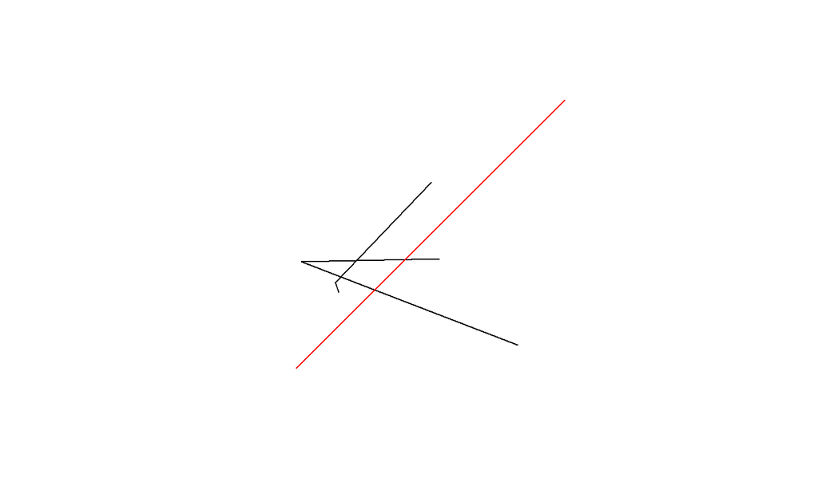

```r
plot(example_spatial_lines_dataframe, col = 1:2)
```

## `SpatialPolygons*`

Al igual que `SpatialLines`, `SpatialPolygons` se contruye con una lista de objetos clase `Polygons`, que a su vez se componen de objetos de clase `Polygon`, que son objetos de clase `Line` cuya coordenada final es igual a la coordenada inicial.

```r
example_bounding_box <- data.frame(
  longitud = c(0, 1, 1, 0, 0),
  latitud = c(0, 0, 1, 1, 0)
)
example_polygon <- Polygon(example_bounding_box)
example_polygons <- Polygons(srl = list(example_polygon), "bounding box")
(example_spatial_polygons <- SpatialPolygons(list(example_polygons), proj4string = example_crs))
```

```
## class       : SpatialPolygons
## features    : 1
## extent      : 0, 1, 0, 1  (xmin, xmax, ymin, ymax)
## coord. ref. : +proj=longlat +datum=WGS84 +ellps=WGS84 +towgs84=0,0,0
```

## `SpatialPolygons*` (cont.)

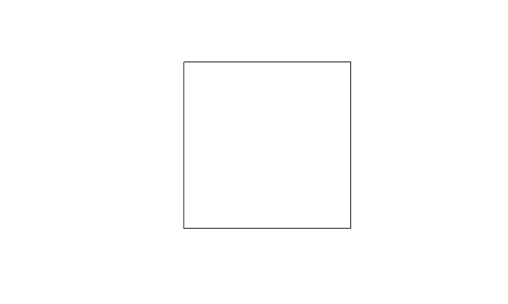

```r
plot(example_spatial_polygons)
```

## `GridTopology` y `SpatialGrid*`

Para crear un objeto de clase `SpatialGrid` necesitamos un objeto clase `GridTopology`. El cual requiere básicamente, un centro y el tamaño de las celdas.

```r
bb <- bbox(example_spatial_polygons)
cs <- c(0.1, 0.2)               # Tamaño de las celdas
cc <- bb[, 1] + cs / 2          # Cordenadas del centroide de inferior izquierdo de la grilla
cd <- ceiling(diff(t(bb))/cs)   # Total de celdas en cada dimensión
example_topology <- GridTopology(cellcentre.offset = cc, cellsize = cs, cells.dim = cd)
example_spatial_grid <- SpatialGrid(example_topology, example_crs)
summary(example_spatial_grid)
```

```
## Object of class SpatialGrid
## Coordinates:
##   min max
## x   0   1
## y   0   1
## Is projected: FALSE
## proj4string :
## [+proj=longlat +datum=WGS84 +ellps=WGS84 +towgs84=0,0,0]
## Grid attributes:
##   cellcentre.offset cellsize cells.dim
## x              0.05      0.1        10
## y              0.10      0.2         5
```

## `GridTopology` y `SpatialGrid*` (cont.)

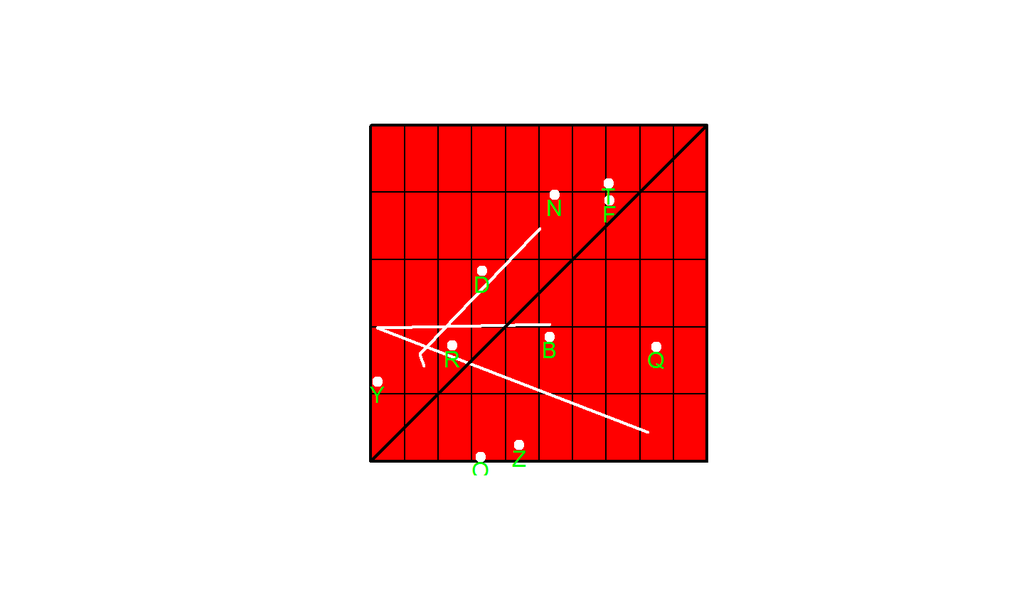

```r
plot(example_spatial_polygons, col = "red", lwd = 2)
plot(example_spatial_grid, add = T)
plot(example_spatial_lines, col = c("white", "black"), lwd = 2, add = T)
points(example_points, col = "white", pch = 19)
text(example_points, labels = spatial_points_df$random_name, pos = 1, offset = 0.2, col = "green")
```

## raster: Geographic Data Analysis and Modeling

## Clases en `raster`

La librería da soporte a las clases:

- `RasterLayer`
- `RasterBrick`
- `RasterStack`

Recomendamos esta librería para soporte de formatos raster, en lugar de `SpatialGrid`. La ventaja de usar la libraría `raster` es que los datos pueden ser analizados **in-memory** o leyendo los archivos del disco. Lo cual da ventaja en rendimiento para archivos grandes.

## `RasterLayer`

Representa una sola capa de datos. Contiene información acerca del origen de los datos, el número de filas y columnas en la grilla.

```r
(example_raster <- raster(
  nrows = 50,       # Número de filas
  ncols = 50,       # Número de columnas
  xmn = 0,        # Coordenada x mínima
  xmx = 1,         # Coordenada x máxima
  ymn = 0,         # Coordenada y mínima
  ymx = 1,          # Coordenada y máxima
  crs = example_crs, # Sistema de coordenadas
  vals = runif(50 ^ 2) * 255
))
```

```
## class       : RasterLayer
## dimensions  : 50, 50, 2500  (nrow, ncol, ncell)
## resolution  : 0.02, 0.02  (x, y)
## extent      : 0, 1, 0, 1  (xmin, xmax, ymin, ymax)
## coord. ref. : +proj=longlat +datum=WGS84 +ellps=WGS84 +towgs84=0,0,0
## data source : in memory
## names       : layer
## values      : 0.005777293, 254.8167  (min, max)
```

## `RasterLayer` (cont.)

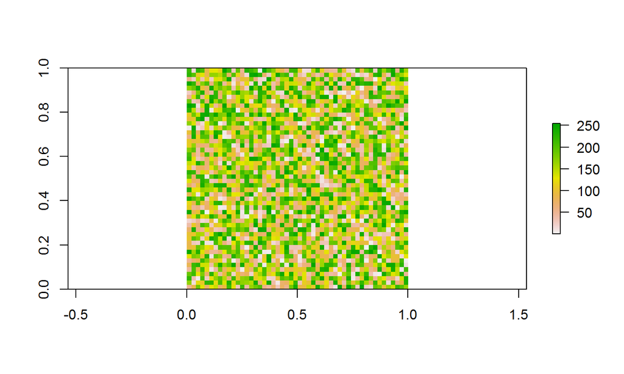

```r
plot(example_raster)
```

## `RasterStack`

Estas clases dan soporte cuando tenemos múltiples capas raster. La diferencia es que `RasterBrick` solo puede ser referenciado a un solo origen y los `RasterStack` a múltiples.

Los archivos `RasterStack` son listas de objetos `RasterLayer` que solo pueden mantenerse en RAM. En cambio, los objetos `RasterBrick` están contenidos en un solo archivo con múltiples *bandas*.

```r
example_raster2 <- raster(
  nrows = 50, ncols = 50, xmn = 0, xmx = 1, ymn = 0, ymx = 1,
  crs = example_crs, vals = rgeom(50 ^ 2, 0.1)
)
example_raster3 <- raster(
  nrows = 50, ncols = 50, xmn = 0, xmx = 1, ymn = 0, ymx = 1,
  crs = example_crs, vals = rpois(50 ^ 2, 100)
)
(raster_stack <- stack(example_raster, example_raster2, example_raster3))
```

```
## class       : RasterStack
## dimensions  : 50, 50, 2500, 3  (nrow, ncol, ncell, nlayers)
## resolution  : 0.02, 0.02  (x, y)
## extent      : 0, 1, 0, 1  (xmin, xmax, ymin, ymax)
## coord. ref. : +proj=longlat +datum=WGS84 +ellps=WGS84 +towgs84=0,0,0
## names       :      layer.1,      layer.2,      layer.3
## min values  :  0.005777293,  0.000000000, 69.000000000
## max values  :     254.8167,      85.0000,     136.0000
```

## `RasterStack` (cont.)

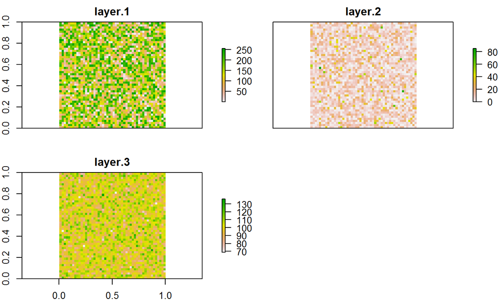

```r
plot(raster_stack)
```

## `RasterStack` (cont.)

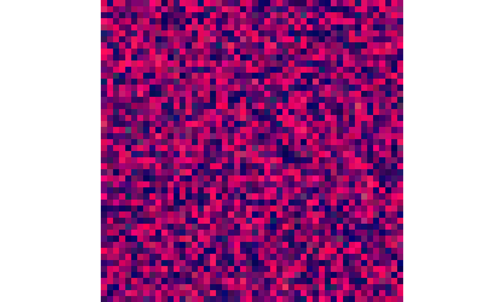

```r
plotRGB(raster_stack)
```

## `RasterBrick`

```r
(raster_brick <- brick(example_raster, example_raster2, example_raster3))
```

```
## class       : RasterBrick
## dimensions  : 50, 50, 2500, 3  (nrow, ncol, ncell, nlayers)
## resolution  : 0.02, 0.02  (x, y)
## extent      : 0, 1, 0, 1  (xmin, xmax, ymin, ymax)
## coord. ref. : +proj=longlat +datum=WGS84 +ellps=WGS84 +towgs84=0,0,0
## data source : in memory
## names       :      layer.1,      layer.2,      layer.3
## min values  :  0.005777293,  0.000000000, 69.000000000
## max values  :     254.8167,      85.0000,     136.0000
```

## sf: Simple Features for R

## Composición de *simple features* y clases en `sf`

Los *simple feature* son el estándar internacional de la representación y manipulación de datos espaciales. La ventaja de usar las *simple features* es intercompatibilidad entre lenguajes y bases de datos, además, el desempeño a mejorado bastante con respecto a `sp` (10x). Los tipos de datos más importantes soportados por `sf` son:

- `POINT`
- `LINESTRING`
- `POLYGON`
- `MULTIPOINT`
- `MULTILINESTRING`
- `MULTIPOLYGON`
- `GEOMETRYCOLLECTION`

## Clase `sf`

La clase `sf` extiende a un `data.frame` con una columna de single features. La columna de single features es un objeto de clase `sfc` (simple feature collection), que es una lista de objetos `sfg` (simple feature geometry).

```r
example_point <- st_point(c(0, 1))
example_line <- st_linestring(matrix(c(0, 1, 0, 1), 2, 2))
outer = matrix(c(0, 0, 10, 0, 10, 10, 0, 10, 0, 0), ncol = 2, byrow = TRUE)
pts = list(outer)
example_polygon <- st_polygon(pts)
class(example_polygon)
```

```
## [1] "XY"      "POLYGON" "sfg"
```

```r
(example_sfc <- st_sfc(example_polygon, example_line))
```

```
## Geometry set for 2 features
## geometry type:  GEOMETRY
## dimension:      XY
## bbox:           xmin: 0 ymin: 0 xmax: 10 ymax: 10
## epsg (SRID):    NA
## proj4string:    NA
```

```
## POLYGON((0 0, 10 0, 10 10, 0 10, 0 0))
```

```
## LINESTRING(0 0, 1 1)
```

## Clase `sf` (Cont.)

```r
(example_sf <- st_sf(a = 1:2, example_sfc))
```

```
## Simple feature collection with 2 features and 1 field
## geometry type:  GEOMETRY
## dimension:      XY
## bbox:           xmin: 0 ymin: 0 xmax: 10 ymax: 10
## epsg (SRID):    NA
## proj4string:    NA
##   a                    example_sfc
## 1 1 POLYGON((0 0, 10 0, 10 10, ...
## 2 2           LINESTRING(0 0, 1 1)
```